```python
import pandas as pd
import scipy.stats as st
import numpy as np
import matplotlib as mpl
import matplotlib.pyplot as plt
import ast
from pedal import *
```

# Helper functions and data

During a lot of the analysis I ended up doing, I noticed I was repeating code. I defined these functions to help decompose and organize my analysis.

```python
clear_report()
def get_called_function(node):
    # use Pedal to get called function
    if node.ast_name == "Attribute":
        left = get_called_function(node.value)
        right = node.attr
        return f"{left}.{right}"
    elif node.ast_name == "Name":
        return node.id
def make_cont_tables(df, headers):
    # make contingency tables for each survey based on prior experience.
    for header in headers:
        print(header + ' totals and contingency table based on prior experience')
        print(df[header].str.strip().str.lower().value_counts())
        display(make_exp_table(df, header))

def make_table_by_q(df, header):
    # make frequency table for one question sliced by survey version
    print(header + ' contingency table')
    table = (pd.crosstab(df.Version, df[header], margins = True))
    # display(table)
    return table

def make_exp_table(df, header):
    # make frequency table for one question sliced by prior experience
    print(header + ' by experience')
    table = pd.crosstab([df.Prior, df.PriorGameDev], df[header].str.lower().str.strip(), margins=True)
    # display(table)
    return table

def perform_all_chi(df, headers):
    # perform chi-square independence test on each question sliced by survey version.
    p_values = []
    for header in headers:
        cont_tbl = pd.crosstab(df['Version'], df[header], margins=False)
        chi = st.chi2_contingency(cont_tbl.values.tolist())
        p_values.append(chi[1])
    return p_values

def perform_exp_chi(df, headers):
    # perform chi-square indpendence test on each question sliced by experience.
    p_values = []
    for header in headers:
        cont_tbl = pd.crosstab([df.Prior, df.PriorGameDev], df[header], margins = False)
        chi = st.chi2_contingency(cont_tbl.values.tolist())
        p_values.append(chi[1])
    return p_values

def analyze_free_response(df, header, exp):
    # analyze free response questions
    pd.set_option("display.max_rows", None, "display.max_columns", None)
    if exp:
        table = make_exp_table(df, header)
        table = table.drop('All', axis=1).dropna().sort_values(('All',''), axis=1, ascending=False)
    else:
        table = make_table_by_q(df, header)
        table = table.drop('All', axis=1).sort_values(by='All', axis=1, ascending=False)

    return table

def analyze_open_end(df, header):
    # analyze open ended code
    total = {
        'methods': 0,
        'functions': 0,
        'both': 0,
        'test cases': 0,
        'graphics': 0,
        'pens': 0,
        'for': 0,
        'while': 0,
        'if': 0,
        'func def': 0
    }
    for code in df[header]:
        methods = False
        functions = False
        clear_report()
        code = str(code)
        calls = find_asts("Call", code)
        num_for = len(find_asts("For", code))
        num_while = len(find_asts("While", code))
        called_functions = [get_called_function(c.func) for c in calls]
        for c in calls:
            if c.func.ast_name == "Name":
                methods = True
            if c.func.ast_name == "Attribute":
                functions = True
        if functions & methods:
            total['both'] += 1
            methods = 0
            functions = 0
        if methods:
            total['methods'] += 1
        if functions:
            total['functions'] += 1
        if "assert_equal" in code:
            total['test cases'] += 1
        if "graphics" in code:
            total['graphics'] += 1
        if " pen" in code:
            total['pens'] += 1
        if 'if' in code:
            total['if'] += 1
        if 'def' in code:
            total['func def'] += 1
        if num_for != 0:
            total['for'] += 1
        if num_while != 0:
            total['while'] += 1
    lines_char = avg_lines_char(df, header)
    show_line_char_graph_calc(lines_char)
    analyze_open_code(df)
    return total

def chi_per_version(headers):
    for header in headers:
        cont_tbl = pd.crosstab([v1.Prior, v1.PriorGameDev], v1[header], margins = False)
        chi = st.chi2_contingency(cont_tbl.values.tolist())
        print(f"p-value of v1 based on prior experience: {chi[1]}")
        cont_tbl = pd.crosstab([v2.Prior, v2.PriorGameDev], v2[header], margins = False)
        chi = st.chi2_contingency(cont_tbl.values.tolist())
        print(f"p-value of v2 based on prior experience: {chi[1]}")


def clean_text(text):
    text = str(text)
    text.lower()
    if 'def' in text:
        text = text.replace('def', '')
    if '()' in text:
        text = text.replace('()', '')
    if text[-1] == 's':
        text = text[:-1]
    text = text.strip()
    return text

def analyze_open_code(df):
    student_programs = df['GameDevOpenCode']
    broken, working = 0, 0
    for program in student_programs:
        try:
            program = str(program)
            ast.parse(program)
            working += 1
        except SyntaxError:
            broken += 1
    print(f"\nBroken: {broken}; Working: {working}")

def show_line_char_graph_calc(lines_char):
    plt.hist(lines_char[0])
    plt.title("distribution of number of lines per response")
    plt.show()
    plt.hist(lines_char[1])
    plt.title("distribution of length of repsonse (in characters)")
    plt.show()
    lines_stat, line_p = st.shapiro(lines_char[0])
    char_stat, char_p = st.shapiro(lines_char[1])
    print("Num Lines Normality on an interval of .05: ", lines_stat, line_p, line_p < 0.05)
    print("Num Characters Normality on an interval of .05: ", char_stat, char_p, char_p < 0.05)

def avg_lines_char(df, header):
    lines_count = 0
    char_count = 0
    student_codes = df[header].dropna()
    num_codes = len(student_codes)
    lines_all = []
    char_all = []
    for code in student_codes:
        code = str(code)
        len_code = len(code)
        lines = (code.count('\n') + 1)
        lines_count += lines
        char_count += len_code
        lines_all.append(lines)
        char_all.append(len_code)
    lines_avg = lines_count / num_codes
    char_avg = char_count / num_codes
    return [lines_all, char_all]
```

### Analysis process

My data comes from two surveys, which I will refer to as survey version one and two. Analysis will be done on each survey individually. Then testing will be conducted to determine when it is appropriate to combine survey results.

### Visualizations

I struggled to decide when to focus on visualizations. I initially used them briefly to determine distribution of the open-ended question. I decided to wait until I understood what my data suggests to focus on visualizations. I made this decision because visualizations should help communicate findings, and I did not know what my data was communicating as I analyzed it. After initial analysis, I went through and tried some different visualizations to see what looked best with the data. I Zoomed with some friends who helped me brainstorm which visuals would be most helpful - which proved to be especially challenging to decide for some of the results sliced multiple ways. I used [this source](https://blog.datawrapper.de/which-color-scale-to-use-in-data-vis/#categorical-color-scales) to determine that I should use different colored hues considering my data is categorical - different hues suggest distinct categories.

# Data Cleaning Survey v1

Load fall 2020 survey 1 data from CSV file.

```python
v1 = pd.read_csv('f20_game_dev_library_data.csv')
v1 = v1.drop(columns=['FinalGrade', 'Midterm', 'CanvasGrade', 'Section', 'Lab', 'TAEngagement', 'TACommunication', 'MeanDiffRank', 'Points', 'Hours Spent in BlockPy', 'Median # of Days Submitted Before Due Date', 'Number of Days Spent Working', 'Assignments With 0s', 'Native Speaker?', 'Location', 'Race/Ethnicity', 'coarse_race', 'PointsGrade', 'MockMidterm14', 'Level', 'OpenPython', 'OpenCode'])
```

Drop rows without survey responses. Filter prior game development experience to yes or no.

```python
v1 = v1.dropna(subset=['PriorGameDev'])
v1['PriorGameDev'] = v1['PriorGameDev'].mask(v1['PriorGameDev'] != 'No.', 'Yes.')
```

define List of headers in both surveys

```python
survey_headers = ['OpenShape', 'OpenScreen', 'ClosedScreen', 'OpenMovement', 'ClosedMovement', 'ClosedWave', 'ClosedStep', 'ClosedEvent', 'ClosedState', 'OpenSprite',
                 'ClosedSprite']
```

# Data Analysis Survey v1

Make table observing distribution of experience levels.

| PriorGameDev Prior | No. | Yes. |
| --- | --- | --- |
| False | 19 | 1 |
| True | 21 | 35 |

```
[19  1 21 35]
```

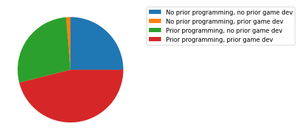

```python
v1_dist = pd.crosstab(v1['Prior'], v1['PriorGameDev'], margins=False)
display(v1_dist)
# v1_dist.groupby(['Prior']).sum().plot.pie(y='No.') -> doesn't show all 4 groups
# v1_dist.sum().plot.pie() -> sums up entire columns, doesn't show all 4 groups
pi_wedges = v1_dist.groupby(['Prior', 'PriorGameDev']).sum().values.flatten()
print(pi_wedges)
wedge_labels = ['No prior programming, no prior game dev', 'No prior programming, prior game dev', 'Prior programming, no prior game dev', 'Prior programming, prior game dev']
# ah got it, gets and flattens 2d array into 1d array that can be passed to matplotlib pyplot
plt.pie(x=pi_wedges)
plt.legend(wedge_labels, bbox_to_anchor=(1.05, 1))
plt.show()
```

Make contingency tables of prior experience levels and survey responses.

```python
make_cont_tables(v1, survey_headers)
```

```
OpenShape totals and contingency table based on prior experience
draw_rectangle                                    13
make_rectangle                                    11
rectangle                                         11
create_rectangle                                   6
draw_square                                        3
rect                                               2
generate_rectangle                                 2
draw_rectangle()                                   2
square                                             2
draw_square()                                      1
generate_square                                    1
integer                                            1
def create_rectangle                               1
def draw_rectangle                                 1
create_shape                                       1
shapes                                             1
rectangle_shape                                    1
g_rectangle                                        1
shape_rectangle                                    1
def draw_rect                                      1
make_box                                           1
shape                                              1
generate.rectangle                                 1
make_rect                                          1
makerectangle                                      1
black_rectangle                                    1
a_rectangle                                        1
def rectangle(length: int, width: int) -> int:     1
generate_rect                                      1
firstrectangle                                     1
cuboid                                             1
turtle                                             1
def rectangle_shape(shape: str)->str:              1
Name: OpenShape, dtype: int64
OpenShape by experience
```

| Prior | OpenShape PriorGameDev | a_rectangle | black_rectangle | create_rectangle | create_shape | cuboid | def create_rectangle | def draw_rect | def draw_rectangle | def rectangle(length: int, width: int) -> int: | def rectangle_shape(shape: str)->str: | draw_rectangle | draw_rectangle() | draw_square | draw_square() | firstrectangle | g_rectangle | generate.rectangle | generate_rect | generate_rectangle | generate_square | integer | make_box | make_rect | make_rectangle | makerectangle | rect | rectangle | rectangle_shape | … |
| --- | --- | --- | --- | --- | --- | --- | --- | --- | --- | --- | --- | --- | --- | --- | --- | --- | --- | --- | --- | --- | --- | --- | --- | --- | --- | --- | --- | --- | --- | --- |
| False | No. | 1 | 0 | 1 | 0 | 1 | 1 | 0 | 0 | 0 | 0 | 0 | 0 | 1 | 0 | 1 | 1 | 1 | 0 | 1 | 0 | 0 | 0 | 0 | 2 | 0 | 0 | 5 | 0 | … |
|  | Yes. | 0 | 0 | 0 | 0 | 0 | 0 | 0 | 0 | 0 | 0 | 0 | 0 | 0 | 0 | 0 | 0 | 0 | 0 | 0 | 0 | 0 | 0 | 0 | 0 | 0 | 0 | 0 | 0 | … |
| True | No. | 0 | 1 | 2 | 1 | 0 | 0 | 0 | 0 | 0 | 1 | 5 | 0 | 0 | 1 | 0 | 0 | 0 | 1 | 1 | 0 | 1 | 0 | 0 | 2 | 0 | 2 | 2 | 0 | … |
|  | Yes. | 0 | 0 | 3 | 0 | 0 | 0 | 1 | 1 | 1 | 0 | 8 | 2 | 2 | 0 | 0 | 0 | 0 | 0 | 0 | 1 | 0 | 1 | 1 | 7 | 1 | 0 | 4 | 1 | … |
| All |  | 1 | 1 | 6 | 1 | 1 | 1 | 1 | 1 | 1 | 1 | 13 | 2 | 3 | 1 | 1 | 1 | 1 | 1 | 2 | 1 | 1 | 1 | 1 | 11 | 1 | 2 | 11 | 1 | … |

```
OpenScreen totals and contingency table based on prior experience
border                                       28
frame                                         6
the border                                    4
borders                                       3
boarder                                       2
perimeter                                     2
window                                        2
edge                                          2
insider of the square                         1
the boarder                                   1
area_of_game                                  1
outs puts                                     1
yellow_border                                 1
outer border                                  1
the boundary                                  1
window, frame, or camera area                 1
yellow_game_border                            1
marginal area                                 1
outline                                       1
frog                                          1
game_window                                   1
margin                                        1
screen                                        1
the frame or boundaries                       1
game perimeter                                1
visuals                                       1
background or border                          1
wall                                          1
the game border                               1
a border                                      1
borderlines                                   1
outer_border                                  1
bounds                                        1
(the_height_length:int, width_length:int)     1
an outline                                    1
Name: OpenScreen, dtype: int64
OpenScreen by experience
```

| Prior | OpenScreen PriorGameDev | (the_height_length:int, width_length:int) | a border | an outline | area_of_game | background or border | boarder | border | borderlines | borders | bounds | edge | frame | frog | game perimeter | game_window | insider of the square | margin | marginal area | outer border | outer_border | outline | outs puts | perimeter | screen | the boarder | the border | the boundary | the frame or boundaries | … |
| --- | --- | --- | --- | --- | --- | --- | --- | --- | --- | --- | --- | --- | --- | --- | --- | --- | --- | --- | --- | --- | --- | --- | --- | --- | --- | --- | --- | --- | --- | --- |
| False | No. | 1 | 1 | 1 | 0 | 0 | 0 | 3 | 1 | 0 | 0 | 2 | 2 | 0 | 0 | 0 | 1 | 1 | 1 | 0 | 0 | 0 | 1 | 1 | 1 | 1 | 0 | 0 | 1 | … |
|  | Yes. | 0 | 0 | 0 | 0 | 0 | 0 | 0 | 0 | 0 | 0 | 0 | 0 | 1 | 0 | 0 | 0 | 0 | 0 | 0 | 0 | 0 | 0 | 0 | 0 | 0 | 0 | 0 | 0 | … |
| True | No. | 0 | 0 | 0 | 1 | 0 | 0 | 6 | 0 | 1 | 0 | 0 | 3 | 0 | 0 | 0 | 0 | 0 | 0 | 1 | 1 | 1 | 0 | 1 | 0 | 0 | 2 | 0 | 0 | … |
|  | Yes. | 0 | 0 | 0 | 0 | 1 | 2 | 19 | 0 | 2 | 1 | 0 | 1 | 0 | 1 | 1 | 0 | 0 | 0 | 0 | 0 | 0 | 0 | 0 | 0 | 0 | 2 | 1 | 0 | … |
| All |  | 1 | 1 | 1 | 1 | 1 | 2 | 28 | 1 | 3 | 1 | 2 | 6 | 1 | 1 | 1 | 1 | 1 | 1 | 1 | 1 | 1 | 1 | 2 | 1 | 1 | 4 | 1 | 1 | … |

```
ClosedScreen totals and contingency table based on prior experience
screen    30
view      23
scene     15
world      4
camera     2
level      2
Name: ClosedScreen, dtype: int64
ClosedScreen by experience
```

| Prior | ClosedScreen PriorGameDev | camera | level | scene | screen | view | world | All |
| --- | --- | --- | --- | --- | --- | --- | --- | --- |
| False | No. | 2 | 1 | 3 | 6 | 4 | 3 | 19 |
|  | Yes. | 0 | 0 | 0 | 1 | 0 | 0 | 1 |
| True | No. | 0 | 1 | 3 | 10 | 7 | 0 | 21 |
|  | Yes. | 0 | 0 | 9 | 13 | 12 | 1 | 35 |
| All |  | 2 | 2 | 15 | 30 | 23 | 4 | 76 |

```
OpenMovement totals and contingency table based on prior experience
moving                                                                                         8
floating                                                                                       6
walking                                                                                        6
sliding                                                                                        6
move                                                                                           5
gliding                                                                                        5
move_right                                                                                     2
walk                                                                                           2
moveright                                                                                      1
repositioning                                                                                  1
move right                                                                                     1
walk_forward                                                                                   1
changing the x value                                                                           1
go forward                                                                                     1
moving a sprite                                                                                1
shifting                                                                                       1
glide                                                                                          1
slide_right                                                                                    1
forward                                                                                        1
slide                                                                                          1
scrolling                                                                                      1
moving forward                                                                                 1
moveforward                                                                                    1
sweeping                                                                                       1
move forward                                                                                   1
horizontal displacement（x move forward?)                                                       1
moving to the right                                                                            1
move_wizard_forward                                                                            1
movements                                                                                      1
hovering with forward momentum                                                                 1
movement                                                                                       1
slow_walking                                                                                   1
moving from left to right --> turtle alphabet project                                          1
animation                                                                                      1
move_left                                                                                      1
changing x position to the right, once it reaches a point it goes back to where it started.    1
move to right                                                                                  1
wizard_man                                                                                     1
translate                                                                                      1
shift                                                                                          1
move.right                                                                                     1
move_forward                                                                                   1
moving right                                                                                   1
constant horizontal translation                                                                1
Name: OpenMovement, dtype: int64
OpenMovement by experience
```

| Prior | OpenMovement PriorGameDev | animation | changing the x value | changing x position to the right, once it reaches a point it goes back to where it started. | constant horizontal translation | floating | forward | glide | gliding | go forward | horizontal displacement（x move forward?) | hovering with forward momentum | move | move forward | move right | move to right | move.right | move_forward | move_left | move_right | move_wizard_forward | moveforward | movement | movements | moveright | moving | moving a sprite | moving forward | moving from left to right --> turtle alphabet project | … |
| --- | --- | --- | --- | --- | --- | --- | --- | --- | --- | --- | --- | --- | --- | --- | --- | --- | --- | --- | --- | --- | --- | --- | --- | --- | --- | --- | --- | --- | --- | --- |
| False | No. | 0 | 0 | 0 | 0 | 3 | 0 | 0 | 1 | 0 | 1 | 1 | 1 | 0 | 0 | 0 | 0 | 0 | 0 | 0 | 1 | 0 | 0 | 1 | 0 | 2 | 0 | 1 | 0 | … |
|  | Yes. | 0 | 0 | 0 | 0 | 0 | 0 | 0 | 0 | 0 | 0 | 0 | 0 | 0 | 0 | 0 | 0 | 0 | 0 | 0 | 0 | 0 | 0 | 0 | 0 | 0 | 0 | 0 | 0 | … |
| True | No. | 0 | 0 | 0 | 0 | 2 | 0 | 0 | 1 | 0 | 0 | 0 | 2 | 1 | 0 | 0 | 1 | 0 | 0 | 0 | 0 | 0 | 1 | 0 | 0 | 1 | 0 | 0 | 1 | … |
|  | Yes. | 1 | 1 | 1 | 1 | 1 | 1 | 1 | 3 | 1 | 0 | 0 | 2 | 0 | 1 | 1 | 0 | 1 | 1 | 2 | 0 | 1 | 0 | 0 | 1 | 5 | 1 | 0 | 0 | … |
| All |  | 1 | 1 | 1 | 1 | 6 | 1 | 1 | 5 | 1 | 1 | 1 | 5 | 1 | 1 | 1 | 1 | 1 | 1 | 2 | 1 | 1 | 1 | 1 | 1 | 8 | 1 | 1 | 1 | … |

```
ClosedMovement totals and contingency table based on prior experience
movement     33
glide        33
animation     7
action        3
Name: ClosedMovement, dtype: int64
ClosedMovement by experience
```

| Prior | ClosedMovement PriorGameDev | action | animation | glide | movement | All |
| --- | --- | --- | --- | --- | --- | --- |
| False | No. | 2 | 1 | 8 | 8 | 19 |
|  | Yes. | 0 | 0 | 0 | 1 | 1 |
| True | No. | 0 | 3 | 10 | 8 | 21 |
|  | Yes. | 1 | 3 | 15 | 16 | 35 |
| All |  | 3 | 7 | 33 | 33 | 76 |

```
ClosedWave totals and contingency table based on prior experience
action       34
animation    31
movement     11
Name: ClosedWave, dtype: int64
ClosedWave by experience
```

| Prior | ClosedWave PriorGameDev | action | animation | movement | All |
| --- | --- | --- | --- | --- | --- |
| False | No. | 10 | 5 | 4 | 19 |
|  | Yes. | 1 | 0 | 0 | 1 |
| True | No. | 9 | 10 | 2 | 21 |
|  | Yes. | 14 | 16 | 5 | 35 |
| All |  | 34 | 31 | 11 | 76 |

```
ClosedStep totals and contingency table based on prior experience
repeat       38
iteration    24
step         12
update        2
Name: ClosedStep, dtype: int64
ClosedStep by experience
```

| Prior | ClosedStep PriorGameDev | iteration | repeat | step | update | All |
| --- | --- | --- | --- | --- | --- | --- |
| False | No. | 5 | 13 | 1 | 0 | 19 |
|  | Yes. | 0 | 1 | 0 | 0 | 1 |
| True | No. | 8 | 6 | 6 | 1 | 21 |
|  | Yes. | 11 | 18 | 5 | 1 | 35 |
| All |  | 24 | 38 | 12 | 2 | 76 |

```
ClosedEvent totals and contingency table based on prior experience
when        35
attach      13
connect     12
register     9
on           7
Name: ClosedEvent, dtype: int64
ClosedEvent by experience
```

| Prior | ClosedEvent PriorGameDev | attach | connect | on | register | when | All |
| --- | --- | --- | --- | --- | --- | --- | --- |
| False | No. | 4 | 6 | 1 | 1 | 7 | 19 |
|  | Yes. | 0 | 1 | 0 | 0 | 0 | 1 |
| True | No. | 3 | 4 | 1 | 4 | 9 | 21 |
|  | Yes. | 6 | 1 | 5 | 4 | 19 | 35 |
| All |  | 13 | 12 | 7 | 9 | 35 | 76 |

```
ClosedState totals and contingency table based on prior experience
state     37
status    24
moment    15
Name: ClosedState, dtype: int64
ClosedState by experience
```

| Prior | ClosedState PriorGameDev | moment | state | status | All |
| --- | --- | --- | --- | --- | --- |
| False | No. | 10 | 4 | 5 | 19 |
|  | Yes. | 0 | 0 | 1 | 1 |
| True | No. | 4 | 10 | 7 | 21 |
|  | Yes. | 1 | 23 | 11 | 35 |
| All |  | 15 | 37 | 24 | 76 |

```
OpenSprite totals and contingency table based on prior experience
objects                         18
characters                      14
sprites                         11
elements                         4
animations                       2
element                          2
figures                          2
object                           1
pictures                         1
cartoons                         1
charecters                       1
game elements                    1
body of object                   1
player                           1
game pieces                      1
component                        1
item                             1
the player and the objective     1
foreground                       1
figure                           1
assets                           1
the verbs. values                1
sceneic_elements                 1
the subjects                     1
entities                         1
special point or movement        1
bubble                           1
character                        1
table                            1
key                              1
Name: OpenSprite, dtype: int64
OpenSprite by experience
```

| Prior | OpenSprite PriorGameDev | animations | assets | body of object | bubble | cartoons | character | characters | charecters | component | element | elements | entities | figure | figures | foreground | game elements | game pieces | item | key | object | objects | pictures | player | sceneic_elements | special point or movement | sprites | table | the player and the objective | … |
| --- | --- | --- | --- | --- | --- | --- | --- | --- | --- | --- | --- | --- | --- | --- | --- | --- | --- | --- | --- | --- | --- | --- | --- | --- | --- | --- | --- | --- | --- | --- |
| False | No. | 0 | 0 | 0 | 1 | 1 | 0 | 3 | 0 | 1 | 1 | 2 | 0 | 1 | 0 | 0 | 0 | 1 | 0 | 0 | 1 | 2 | 1 | 0 | 0 | 1 | 1 | 1 | 0 | … |
|  | Yes. | 0 | 0 | 0 | 0 | 0 | 0 | 0 | 0 | 0 | 0 | 0 | 0 | 0 | 0 | 0 | 0 | 0 | 1 | 0 | 0 | 0 | 0 | 0 | 0 | 0 | 0 | 0 | 0 | … |
| True | No. | 1 | 1 | 1 | 0 | 0 | 0 | 5 | 0 | 0 | 0 | 0 | 1 | 0 | 2 | 0 | 0 | 0 | 0 | 1 | 0 | 7 | 0 | 0 | 0 | 0 | 1 | 0 | 0 | … |
|  | Yes. | 1 | 0 | 0 | 0 | 0 | 1 | 6 | 1 | 0 | 1 | 2 | 0 | 0 | 0 | 1 | 1 | 0 | 0 | 0 | 0 | 9 | 0 | 1 | 1 | 0 | 9 | 0 | 1 | … |
| All |  | 2 | 1 | 1 | 1 | 1 | 1 | 14 | 1 | 1 | 2 | 4 | 1 | 1 | 2 | 1 | 1 | 1 | 1 | 1 | 1 | 18 | 1 | 1 | 1 | 1 | 11 | 1 | 1 | … |

```
ClosedSprite totals and contingency table based on prior experience
objects       35
characters    21
sprites       20
Name: ClosedSprite, dtype: int64
ClosedSprite by experience
```

| Prior | ClosedSprite PriorGameDev | characters | objects | sprites | All |
| --- | --- | --- | --- | --- | --- |
| False | No. | 4 | 12 | 3 | 19 |
|  | Yes. | 0 | 1 | 0 | 1 |
| True | No. | 10 | 7 | 4 | 21 |
|  | Yes. | 7 | 15 | 13 | 35 |
| All |  | 21 | 35 | 20 | 76 |

# Data Cleaning Spring 21 Survey v2

Load spring 2021 survey 2 data from CSV file and format file.

```python
v2 = pd.read_csv('s21_game_dev_library_data.csv')
column_names = v2.iloc[0]
v2.columns = column_names
v2 = v2.drop([0, 1])
v2 = v2.reset_index(drop=True)
```

Remove columns from results not pertinent to data analysis.

```python
v2 = v2.drop(columns=['Status', 'IPAddress', 'Duration (in seconds)', 'Progress', 'Finished', 'RecordedDate', 'ResponseId', 'RecipientLastName',
                     'RecipientFirstName', 'RecipientEmail', 'ExternalReference', 'LocationLatitude', 'LocationLongitude', 'DistributionChannel', 'UserLanguage'])
```

Remove non-consenting responses and determine number of participants.

```python
v2 = v2[v2.Q16 != 'I do not consent to participate in the research study.']
print('Number of consenting participants: ' + str(len(v2)))
```

```
Number of consenting participants: 118
```

Filter prior experience question to True/False

```python
v2['PriorGameDev'] = v2['PriorGameDev'].mask(v2['PriorGameDev'] != 'No.', 'Yes.')
v2['Prior'] = v2['Prior'].mask(v2['Prior'] != ('None'), True)
v2['Prior'] = v2['Prior'].mask(v2['Prior'] != True, False)
```

Get gender demographics

```python
v2['Gender'].value_counts()
```

```
Man                         67
Woman                       39
Man,Prefer not to answer     1
Name: Gender, dtype: int64
```

# Data Analysis Survey v2

Edit `survey_headers` to account for changes to survey.

```python
survey_headers.remove('OpenMovement')
survey_headers
```

```
['OpenShape',
 'OpenScreen',
 'ClosedScreen',
 'ClosedMovement',
 'ClosedWave',
 'ClosedStep',
 'ClosedEvent',
 'ClosedState',
 'OpenSprite',
 'ClosedSprite']
```

Find participants per levels of experience.

| PriorGameDev Prior | No. | Yes. |
| --- | --- | --- |
| False | 51 | 5 |
| True | 31 | 31 |

```
[51  5 31 31]
```

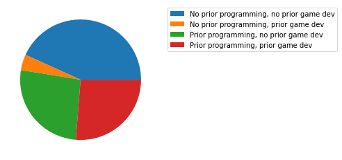

```python
v2_dist = pd.crosstab(v2['Prior'], v2['PriorGameDev'], margins=False)
display(v2_dist)
pi_wedges = v2_dist.groupby(['Prior', 'PriorGameDev']).sum().values.flatten()
print(pi_wedges)
wedge_labels = ['No prior programming, no prior game dev', 'No prior programming, prior game dev', 'Prior programming, no prior game dev', 'Prior programming, prior game dev']
plt.pie(x=pi_wedges)
plt.legend(wedge_labels, bbox_to_anchor=(1.05, 1))
plt.show()
```

Compared to v1, different distribution of experience. Noticably more participants without prior levels of experience.

```python
make_cont_tables(v2, survey_headers)
```

```
OpenShape totals and contingency table based on prior experience
rectangle                                                                                                                                                               44
draw_rectangle                                                                                                                                                           5
rectangle()                                                                                                                                                              4
generate_rectangle                                                                                                                                                       4
create_rectangle                                                                                                                                                         3
i don't know                                                                                                                                                             2
shape                                                                                                                                                                    2
def rectangle()                                                                                                                                                          2
game shape                                                                                                                                                               1
i do not know                                                                                                                                                            1
def create_rectangle                                                                                                                                                     1
make_rect()                                                                                                                                                              1
drawrectangle()                                                                                                                                                          1
create_rectangle()                                                                                                                                                       1
draw_rect                                                                                                                                                                1
???                                                                                                                                                                      1
determine(shape)                                                                                                                                                         1
ziang zhou                                                                                                                                                               1
drawing()                                                                                                                                                                1
box                                                                                                                                                                      1
rect                                                                                                                                                                     1
draw                                                                                                                                                                     1
a                                                                                                                                                                        1
dian gu()                                                                                                                                                                1
def rectangle ():                                                                                                                                                        1
gen_rectangle                                                                                                                                                            1
return function                                                                                                                                                          1
createrectangle()                                                                                                                                                        1
draw_rectangle()                                                                                                                                                         1
make_rectangle                                                                                                                                                           1
empty_rectangle                                                                                                                                                          1
```

[output cut: 17 more lines]

| Prior | OpenShape PriorGameDev | ??? | a | box | create_rectangle | create_rectangle() | create_square | createrectangle() | def create_rectangle | def rectangle (): | def rectangle() | defrectangle(): | determine(shape) | dian gu() | draw | draw("box") | draw_rect | draw_rectangle | draw_rectangle() | drawing() | drawrectangle() | empty_rectangle | form_rectangle | game shape | gen_rectangle | generate_rect | generate_rectangle | i am unsure as to the function that makes this shape. | i do not know | … |
| --- | --- | --- | --- | --- | --- | --- | --- | --- | --- | --- | --- | --- | --- | --- | --- | --- | --- | --- | --- | --- | --- | --- | --- | --- | --- | --- | --- | --- | --- | --- |
| False | No. | 1 | 1 | 1 | 3 | 0 | 0 | 0 | 1 | 0 | 1 | 1 | 1 | 0 | 1 | 0 | 0 | 3 | 0 | 0 | 0 | 1 | 1 | 0 | 1 | 0 | 2 | 1 | 1 | … |
|  | Yes. | 0 | 0 | 0 | 0 | 0 | 0 | 0 | 0 | 0 | 0 | 0 | 0 | 1 | 0 | 0 | 0 | 0 | 0 | 0 | 0 | 0 | 0 | 0 | 0 | 0 | 0 | 0 | 0 | … |
| True | No. | 0 | 0 | 0 | 0 | 1 | 0 | 0 | 0 | 1 | 0 | 0 | 0 | 0 | 0 | 1 | 1 | 1 | 1 | 0 | 0 | 0 | 0 | 0 | 0 | 1 | 2 | 0 | 0 | … |
|  | Yes. | 0 | 0 | 0 | 0 | 0 | 1 | 1 | 0 | 0 | 1 | 0 | 0 | 0 | 0 | 0 | 0 | 1 | 0 | 1 | 1 | 0 | 0 | 1 | 0 | 0 | 0 | 0 | 0 | … |
| All |  | 1 | 1 | 1 | 3 | 1 | 1 | 1 | 1 | 1 | 2 | 1 | 1 | 1 | 1 | 1 | 1 | 5 | 1 | 1 | 1 | 1 | 1 | 1 | 1 | 1 | 4 | 1 | 1 | … |

```
OpenScreen totals and contingency table based on prior experience
border                                      32
screen                                       4
frame                                        4
play area                                    3
square                                       3
outline                                      2
boarder                                      2
candy frog                                   2
window                                       2
board                                        2
i don't know                                 2
game_area                                    2
main_screen                                  2
display                                      2
border or perimeter                          1
perimeter                                    1
area_of_square                               1
whitespace                                   1
a boarder                                    1
design function                              1
game zone                                    1
main frame                                   1
i am not familiar with this terminology.     1
the border                                   1
border_area                                  1
frame or border                              1
sweet-tongue                                 1
game screen perimeter                        1
stage                                        1
the game                                     1
area                                         1
game area                                    1
game activity                                1
profile                                      1
game space                                   1
box                                          1
i do not know                                1
body                                         1
game screen                                  1
display or in game                           1
empty space out of the square border         1
emulator                                     1
a border                                     1
gamescreen()                                 1
game_window                                  1
the window of the game/the screen            1
limit                                        1
boundary                                     1
interface                                    1
viewing window                               1
borders                                      1
the outline                                  1
yellow_area                                  1
game bounds                                  1
display_screen                               1
the workspace, canvas, or "sandbox"          1
Name: OpenScreen, dtype: int64
OpenScreen by experience
```

| Prior | OpenScreen PriorGameDev | a boarder | a border | area | area_of_square | board | boarder | body | border | border or perimeter | border_area | borders | boundary | box | candy frog | design function | display | display or in game | display_screen | empty space out of the square border | emulator | frame | frame or border | game activity | game area | game bounds | game screen | game screen perimeter | game space | … |
| --- | --- | --- | --- | --- | --- | --- | --- | --- | --- | --- | --- | --- | --- | --- | --- | --- | --- | --- | --- | --- | --- | --- | --- | --- | --- | --- | --- | --- | --- | --- |
| False | No. | 0 | 1 | 0 | 0 | 1 | 1 | 0 | 16 | 0 | 1 | 1 | 0 | 0 | 0 | 1 | 0 | 1 | 1 | 0 | 1 | 1 | 1 | 1 | 1 | 0 | 1 | 0 | 0 | … |
|  | Yes. | 0 | 0 | 1 | 0 | 0 | 0 | 0 | 0 | 0 | 0 | 0 | 1 | 0 | 0 | 0 | 0 | 0 | 0 | 1 | 0 | 0 | 0 | 0 | 0 | 0 | 0 | 0 | 0 | … |
| True | No. | 0 | 0 | 0 | 1 | 1 | 1 | 0 | 12 | 0 | 0 | 0 | 0 | 0 | 1 | 0 | 1 | 0 | 0 | 0 | 0 | 1 | 0 | 0 | 0 | 1 | 0 | 1 | 1 | … |
|  | Yes. | 1 | 0 | 0 | 0 | 0 | 0 | 1 | 4 | 1 | 0 | 0 | 0 | 1 | 1 | 0 | 1 | 0 | 0 | 0 | 0 | 2 | 0 | 0 | 0 | 0 | 0 | 0 | 0 | … |
| All |  | 1 | 1 | 1 | 1 | 2 | 2 | 1 | 32 | 1 | 1 | 1 | 1 | 1 | 2 | 1 | 2 | 1 | 1 | 1 | 1 | 4 | 1 | 1 | 1 | 1 | 1 | 1 | 1 | … |

```
ClosedScreen totals and contingency table based on prior experience
window    53
screen    22
scene     12
world      7
level      7
view       6
Name: ClosedScreen, dtype: int64
ClosedScreen by experience
```

| Prior | ClosedScreen PriorGameDev | level | scene | screen | view | window | world | All |
| --- | --- | --- | --- | --- | --- | --- | --- | --- |
| False | No. | 1 | 2 | 12 | 3 | 28 | 5 | 51 |
|  | Yes. | 0 | 0 | 2 | 0 | 3 | 0 | 5 |
| True | No. | 3 | 5 | 3 | 1 | 16 | 2 | 30 |
|  | Yes. | 3 | 5 | 5 | 2 | 6 | 0 | 21 |
| All |  | 7 | 12 | 22 | 6 | 53 | 7 | 107 |

```
ClosedMovement totals and contingency table based on prior experience
animation    50
glide        30
movement     23
action        5
Name: ClosedMovement, dtype: int64
ClosedMovement by experience
```

| Prior | ClosedMovement PriorGameDev | action | animation | glide | movement | All |
| --- | --- | --- | --- | --- | --- | --- |
| False | No. | 2 | 28 | 10 | 11 | 51 |
|  | Yes. | 0 | 3 | 2 | 0 | 5 |
| True | No. | 2 | 10 | 13 | 6 | 31 |
|  | Yes. | 1 | 9 | 5 | 6 | 21 |
| All |  | 5 | 50 | 30 | 23 | 108 |

```
ClosedWave totals and contingency table based on prior experience
animation    51
action       39
movement     18
Name: ClosedWave, dtype: int64
ClosedWave by experience
```

| Prior | ClosedWave PriorGameDev | action | animation | movement | All |
| --- | --- | --- | --- | --- | --- |
| False | No. | 14 | 28 | 9 | 51 |
|  | Yes. | 1 | 1 | 3 | 5 |
| True | No. | 14 | 15 | 2 | 31 |
|  | Yes. | 10 | 7 | 4 | 21 |
| All |  | 39 | 51 | 18 | 108 |

```
ClosedStep totals and contingency table based on prior experience
repeat       61
iteration    38
step          7
update        2
Name: ClosedStep, dtype: int64
ClosedStep by experience
```

| Prior | ClosedStep PriorGameDev | iteration | repeat | step | update | All |
| --- | --- | --- | --- | --- | --- | --- |
| False | No. | 16 | 31 | 4 | 0 | 51 |
|  | Yes. | 1 | 4 | 0 | 0 | 5 |
| True | No. | 9 | 18 | 3 | 1 | 31 |
|  | Yes. | 12 | 8 | 0 | 1 | 21 |
| All |  | 38 | 61 | 7 | 2 | 108 |

```
ClosedEvent totals and contingency table based on prior experience
when        40
attach      23
connect     19
register    15
on          11
Name: ClosedEvent, dtype: int64
ClosedEvent by experience
```

| Prior | ClosedEvent PriorGameDev | attach | connect | on | register | when | All |
| --- | --- | --- | --- | --- | --- | --- | --- |
| False | No. | 12 | 12 | 4 | 10 | 13 | 51 |
|  | Yes. | 1 | 0 | 1 | 1 | 2 | 5 |
| True | No. | 7 | 4 | 2 | 3 | 15 | 31 |
|  | Yes. | 3 | 3 | 4 | 1 | 10 | 21 |
| All |  | 23 | 19 | 11 | 15 | 40 | 108 |

```
ClosedState totals and contingency table based on prior experience
state     37
moment    35
status    33
world      3
Name: ClosedState, dtype: int64
ClosedState by experience
```

| Prior | ClosedState PriorGameDev | moment | state | status | world | All |
| --- | --- | --- | --- | --- | --- | --- |
| False | No. | 18 | 18 | 13 | 2 | 51 |
|  | Yes. | 3 | 1 | 1 | 0 | 5 |
| True | No. | 8 | 11 | 12 | 0 | 31 |
|  | Yes. | 6 | 7 | 7 | 1 | 21 |
| All |  | 35 | 37 | 33 | 3 | 108 |

```
OpenSprite totals and contingency table based on prior experience
characters                                                 16
objects                                                    12
candy                                                       6
character                                                   5
object                                                      5
items                                                       4
sprites                                                     4
entities                                                    3
sprite                                                      3
figures                                                     3
assets                                                      3
objectives                                                  2
figure                                                      2
animations                                                  2
icons                                                       2
i am not sure what the highlighted elements are called.     1
cindy                                                       1
elements, objects, figures, characters                      1
extras                                                      1
creature                                                    1
the target                                                  1
visual elements or objects                                  1
cpu's                                                       1
game elements                                               1
mission                                                     1
characters, subjects and objects, targets                   1
bubbles                                                     1
base                                                        1
game                                                        1
frog, candy, and ground                                     1
things                                                      1
elements                                                    1
models                                                      1
frog and bug                                                1
avatars                                                     1
movingelement()                                             1
game_enviro                                                 1
bug                                                         1
components                                                  1
item                                                        1
virtual item                                                1
animals                                                     1
candy in the air                                            1
parts                                                       1
features                                                    1
main parts                                                  1
checkpoint                                                  1
game components                                             1
objects in the screen                                       1
Name: OpenSprite, dtype: int64
OpenSprite by experience
```

| Prior | OpenSprite PriorGameDev | animals | animations | assets | avatars | base | bubbles | bug | candy | candy in the air | character | characters | characters, subjects and objects, targets | checkpoint | cindy | components | cpu's | creature | elements | elements, objects, figures, characters | entities | extras | features | figure | figures | frog and bug | frog, candy, and ground | game | game components | … |
| --- | --- | --- | --- | --- | --- | --- | --- | --- | --- | --- | --- | --- | --- | --- | --- | --- | --- | --- | --- | --- | --- | --- | --- | --- | --- | --- | --- | --- | --- | --- |
| False | No. | 1 | 0 | 2 | 0 | 1 | 1 | 1 | 3 | 0 | 2 | 11 | 1 | 0 | 0 | 1 | 0 | 1 | 1 | 0 | 2 | 0 | 1 | 1 | 2 | 0 | 0 | 1 | 1 | … |
|  | Yes. | 0 | 0 | 0 | 0 | 0 | 0 | 0 | 0 | 1 | 1 | 0 | 0 | 0 | 0 | 0 | 0 | 0 | 0 | 0 | 0 | 1 | 0 | 0 | 0 | 0 | 0 | 0 | 0 | … |
| True | No. | 0 | 1 | 0 | 1 | 0 | 0 | 0 | 1 | 0 | 1 | 3 | 0 | 1 | 0 | 0 | 1 | 0 | 0 | 1 | 0 | 0 | 0 | 1 | 1 | 1 | 1 | 0 | 0 | … |
|  | Yes. | 0 | 1 | 1 | 0 | 0 | 0 | 0 | 2 | 0 | 1 | 2 | 0 | 0 | 1 | 0 | 0 | 0 | 0 | 0 | 1 | 0 | 0 | 0 | 0 | 0 | 0 | 0 | 0 | … |
| All |  | 1 | 2 | 3 | 1 | 1 | 1 | 1 | 6 | 1 | 5 | 16 | 1 | 1 | 1 | 1 | 1 | 1 | 1 | 1 | 3 | 1 | 1 | 2 | 3 | 1 | 1 | 1 | 1 | … |

```
ClosedSprite totals and contingency table based on prior experience
objects       42
characters    33
sprites       27
images         2
pixels         1
drawables      1
pictures       1
Name: ClosedSprite, dtype: int64
ClosedSprite by experience
```

| Prior | ClosedSprite PriorGameDev | characters | drawables | images | objects | pictures | pixels | sprites | All |
| --- | --- | --- | --- | --- | --- | --- | --- | --- | --- |
| False | No. | 21 | 0 | 1 | 16 | 1 | 1 | 11 | 51 |
|  | Yes. | 2 | 1 | 0 | 2 | 0 | 0 | 0 | 5 |
| True | No. | 7 | 0 | 1 | 13 | 0 | 0 | 10 | 31 |
|  | Yes. | 3 | 0 | 0 | 11 | 0 | 0 | 6 | 20 |
| All |  | 33 | 1 | 2 | 42 | 1 | 1 | 27 | 107 |

# Compare Survey v1 and v2 Distributions

Compare responses from surveys 1 and 2 with Chi-Square Independence Test.

Perform Chi-Square Independence Test for every shared survey question.

If significant difference based on survey version, investigate relationship between responses per survey version and prior experience.

```python
v1['Version'] = 1
v2['Version'] = 2
total = pd.concat([v1, v2])
total['ClosedSprite'] = total['ClosedSprite'].str.strip().str.lower()
total['OpenShape'] = total['OpenShape'].str.lower()
all_chi = perform_all_chi(total, survey_headers)
exp_chi = perform_exp_chi(total, survey_headers)
total_p_values = pd.DataFrame(list(zip(all_chi, exp_chi)), columns=['sliced by survey version', 'sliced by experience'], index=survey_headers).transpose()
print("P-Values from Chi Square Independence Test performed individually by survey version and experience level: ")
display(total_p_values)
print("P-Values from Chi Square Indpendence Test performed by experience level on responses with significant difference based on survey version: ")
version_headers = ['OpenShape', 'ClosedScreen', 'ClosedMovement']
exp_chi_version1 = perform_exp_chi(v1, version_headers)
exp_chi_version2= perform_exp_chi(v2, version_headers)
pd.DataFrame(list(zip(exp_chi_version1, exp_chi_version2)), columns=['v1', 'v2'], index=version_headers).transpose()
```

```
P-Values from Chi Square Independence Test performed individually by survey version and experience level:
```

|  | OpenShape | OpenScreen | ClosedScreen | ClosedMovement | ClosedWave | ClosedStep | ClosedEvent | ClosedState | OpenSprite | ClosedSprite |
| --- | --- | --- | --- | --- | --- | --- | --- | --- | --- | --- |
| sliced by survey version | 0.008233 | 0.422553 | 1.857338e-12 | 0.000001 | 0.499849 | 0.222499 | 0.815481 | 0.069710 | 0.158248 | 0.647583 |
| sliced by experience | 0.333725 | 0.011658 | 7.237847e-03 | 0.249262 | 0.152158 | 0.237950 | 0.149999 | 0.040338 | 0.019545 | 0.001064 |

```
P-Values from Chi Square Indpendence Test performed by experience level on responses with significant difference based on survey version:
```

|  | OpenShape | ClosedScreen | ClosedMovement |
| --- | --- | --- | --- |
| v1 | 0.185385 | 0.297430 | 0.786123 |
| v2 | 0.818702 | 0.168839 | 0.494844 |

## Pooling V1 and V2 when appropriate

Maintain total responses from surveys for questions with no significant difference and unusable data ('OpenScreen' that did not measure proper concept).

For each question:

- If significant difference was calculated between experience levels, investigate differences between subgroups
- If no significant difference, investigate overall preferences

```python
upd_total = total.drop(['OpenShape', 'OpenScreen', 'ClosedScreen', 'ClosedMovement', 'OpenMovement'], axis=1)
```

#### ClosedWave

No significant difference based on experience.

```
Animation    82
Action       73
Movement     29
Name: ClosedWave, dtype: int64
```

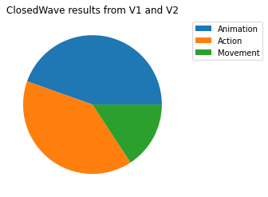

```python
wave_total = upd_total['ClosedWave'].value_counts()
plt.pie(x=wave_total)
print(wave_total)
plt.title('ClosedWave results from V1 and V2')
plt.legend(['Animation', 'Action', 'Movement'], bbox_to_anchor=(1.05, 1))
plt.show()
```

'animation' and 'action' closely frequent.

### ClosedStep

No significant difference based on experience.

```
Repeat       99
Iteration    62
Step         19
Update        4
Name: ClosedStep, dtype: int64
```

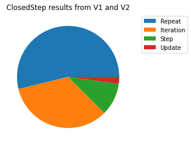

```python
step_total = upd_total['ClosedStep'].value_counts()
plt.pie(x=step_total)
print(step_total)
plt.title('ClosedStep results from V1 and V2')
plt.legend(['Repeat', 'Iteration', 'Step', 'Update'], bbox_to_anchor=(1.05, 1))
plt.show()
```

'repeat' most frequent, 'iteration' also fairly popular.

### ClosedEvent

No significant difference based on experience.

```
When        75
Attach      36
Connect     31
Register    24
On          18
Name: ClosedEvent, dtype: int64
```

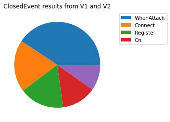

```python
event_total = upd_total['ClosedEvent'].value_counts()
plt.pie(x=event_total)
print(event_total)
plt.title('ClosedEvent results from V1 and V2')
plt.legend(['When' 'Attach', 'Connect', 'Register', 'On'], bbox_to_anchor=(1.05, 1))
plt.show()
```

'when' evidently most common.

### ClosedState

Significant difference based on experience.

```
ClosedState by experience
```

| Prior | ClosedState PriorGameDev | moment | state | status | world | All |
| --- | --- | --- | --- | --- | --- | --- |
| False | No. | 28 | 22 | 18 | 2 | 70 |
|  | Yes. | 3 | 1 | 2 | 0 | 6 |
| True | No. | 12 | 21 | 19 | 0 | 52 |
|  | Yes. | 7 | 30 | 18 | 1 | 56 |

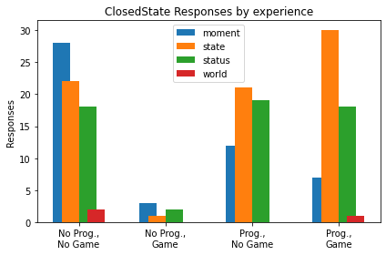

```python
state_total = make_exp_table(upd_total, 'ClosedState')
# state_total.xs('No.', level='PriorGameDev') multi-indexing
# state_total['moment']
state_total = state_total.drop(labels="All", axis=0)
display(state_total)
# no_prior = state_total.iloc[0]
moment = state_total['moment']
# plt.bar(x =['moment', 'state', "status", 'world'], height=no_prior)
# plt.show()
# labels = ['moment', 'state', "status", 'world']
labels = ['No Prog.,\nNo Game', 'No Prog.,\nGame', 'Prog.,\nNo Game', 'Prog.,\nGame']
x = np.arange(len(labels))
width = .20
fig, ax = plt.subplots()
moment_bar = ax.bar(x - width, moment, width, label="moment")
# nppg = state_total.iloc[1]
state = state_total['state']
state_bar = ax.bar(x - width/2, state, width, label="state")
status = state_total['status']
status_bar = ax.bar(x + width/2, status, width, label='status')
world = state_total['world']
world_bar = ax.bar(x + width, world, width, label='world')
ax.set_title('ClosedState Responses by experience')
ax.set_ylabel('Responses')
ax.set_xticks(x)
ax.set_xticklabels(labels)
ax.legend()
fig.tight_layout()
```

As initially noticed in V1, 'moment' is more popular among participants without prior game development experience and not as popular among students with game development and programming experience. 'state' is still most popular overall.

### OpenSprite

Significant difference based on experience.

I don't even know how I'd visualize this.

```python
upd_total['OpenSprite'].dropna().apply(clean_text)
display(analyze_free_response(upd_total, 'OpenSprite', True))
```

```
OpenSprite by experience
```

| Prior | OpenSprite PriorGameDev | objects | characters | sprites | character | candy | object | figures | elements | animations | items | entities | assets | sprite | figure | objectives | game elements | icons | element | item | mission | main parts | models | key | movingelement() | animals | objects in the screen | pictures | player | … |
| --- | --- | --- | --- | --- | --- | --- | --- | --- | --- | --- | --- | --- | --- | --- | --- | --- | --- | --- | --- | --- | --- | --- | --- | --- | --- | --- | --- | --- | --- | --- |
| False | No. | 8 | 14 | 2 | 2 | 3 | 3 | 2 | 3 | 0 | 1 | 2 | 2 | 0 | 2 | 1 | 1 | 1 | 1 | 0 | 0 | 1 | 0 | 0 | 0 | 1 | 0 | 1 | 0 | … |
|  | Yes. | 1 | 0 | 0 | 1 | 0 | 0 | 0 | 0 | 0 | 0 | 0 | 0 | 0 | 0 | 0 | 0 | 0 | 0 | 1 | 1 | 0 | 0 | 0 | 0 | 0 | 0 | 0 | 0 | … |
| True | No. | 9 | 8 | 3 | 1 | 1 | 3 | 3 | 0 | 2 | 2 | 1 | 1 | 1 | 1 | 0 | 0 | 0 | 0 | 0 | 0 | 0 | 1 | 1 | 0 | 0 | 1 | 0 | 0 | … |
|  | Yes. | 12 | 8 | 10 | 2 | 2 | 0 | 0 | 2 | 2 | 1 | 1 | 1 | 2 | 0 | 1 | 1 | 1 | 1 | 1 | 0 | 0 | 0 | 0 | 1 | 0 | 0 | 0 | 1 | … |
| All |  | 30 | 30 | 15 | 6 | 6 | 6 | 5 | 5 | 4 | 4 | 4 | 4 | 3 | 3 | 2 | 2 | 2 | 2 | 2 | 1 | 1 | 1 | 1 | 1 | 1 | 1 | 1 | 1 | … |

### Closed Sprite

Signficantly difference based on experience.

```
ClosedSprite by experience
```

| Prior | ClosedSprite PriorGameDev | All | objects | characters | sprites | images | drawables | pictures | pixels |
| --- | --- | --- | --- | --- | --- | --- | --- | --- | --- |
| False | No. | 70 | 28 | 25 | 14 | 1 | 0 | 1 | 1 |
|  | Yes. | 6 | 3 | 2 | 0 | 0 | 1 | 0 | 0 |
| True | No. | 52 | 20 | 17 | 14 | 1 | 0 | 0 | 0 |
|  | Yes. | 55 | 26 | 10 | 19 | 0 | 0 | 0 | 0 |

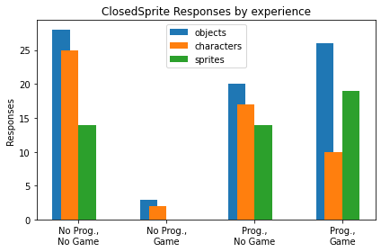

```python
sprite = make_exp_table(upd_total, 'ClosedSprite').sort_values(('All',''), axis=1, ascending=False)
sprite = sprite.drop(labels="All", axis=0)
display(sprite)
objects = sprite['objects']
labels = ['No Prog.,\nNo Game', 'No Prog.,\nGame', 'Prog.,\nNo Game', 'Prog.,\nGame']
x = np.arange(len(labels))
width = .20
fig, ax = plt.subplots()
objects_bar = ax.bar(x - width, objects, width, label="objects")
characters = sprite['characters']
char_bar = ax.bar(x - width/2, characters, width, label="characters")
sprites = sprite['sprites']
sprites_bar = ax.bar(x + width/2, sprites, width, label='sprites')
ax.set_title('ClosedSprite Responses by experience')
ax.set_ylabel('Responses')
ax.set_xticks(x)
ax.set_xticklabels(labels)
ax.legend()
fig.tight_layout()
```

More participants without prior game development experience preferred characters. Objects most popular overall.

## When V1 and V2 data cannot be pooled

Investigating responses with signficant differences between V1 and V2.

## OpenShape

```python
total['OpenShape'] = total['OpenShape'].apply(clean_text)
analyze_free_response(total, 'OpenShape', False)
```

```
OpenShape contingency table
```

| OpenShape Version | rectangle | draw_rectangle | nan | make_rectangle | create_rectangle | generate_rectangle | shape | draw_square | rect | generate_rect | square | make_rect | makerectangle | draw_rect | i don't know | name: rec. description: rec returns a rectangle after given its length and width. syntax: rec(length,width). parameters: length(int), width(int). returns: rectangle | make_box | print | ??? | rectangle : | rectangle(length: int, width: int) -> int: | rectangle: | rectangle_shape | rectangle_shape(shape: str)->str: | return function | shape = rectangle | shape_rectangle | t.foward.t.left.t.down.t.right | turtle | … |
| --- | --- | --- | --- | --- | --- | --- | --- | --- | --- | --- | --- | --- | --- | --- | --- | --- | --- | --- | --- | --- | --- | --- | --- | --- | --- | --- | --- | --- | --- | --- |
| 1 | 11 | 16 | 0 | 11 | 7 | 2 | 2 | 4 | 2 | 1 | 2 | 1 | 1 | 1 | 0 | 0 | 1 | 0 | 0 | 0 | 1 | 0 | 1 | 1 | 0 | 0 | 1 | 0 | 1 | … |
| 2 | 51 | 6 | 14 | 1 | 5 | 4 | 3 | 0 | 2 | 1 | 0 | 1 | 1 | 1 | 2 | 1 | 0 | 1 | 1 | 1 | 0 | 1 | 0 | 0 | 1 | 1 | 0 | 1 | 0 | … |
| All | 62 | 22 | 14 | 12 | 12 | 6 | 5 | 4 | 4 | 2 | 2 | 2 | 2 | 2 | 2 | 1 | 1 | 1 | 1 | 1 | 1 | 1 | 1 | 1 | 1 | 1 | 1 | 1 | 1 | … |

`rectangle` more popular in V2, `draw_rectangle` more popular in V1.

## ClosedScreen

Significant based on survey version. Visualizations are weird with added option.

```
ClosedScreen contingency table
```

| ClosedScreen Version | All | Window | Screen | View | Scene | World | Level | Camera |
| --- | --- | --- | --- | --- | --- | --- | --- | --- |
| 1 | 76 | 0 | 30 | 23 | 15 | 4 | 2 | 2 |
| 2 | 107 | 53 | 22 | 6 | 12 | 7 | 7 | 0 |
| All | 183 | 53 | 52 | 29 | 27 | 11 | 9 | 2 |

| ClosedScreen Version | Window | Screen | View | Scene | World | Level | Camera |
| --- | --- | --- | --- | --- | --- | --- | --- |
| 1 | 0 | 30 | 23 | 15 | 4 | 2 | 2 |
| 2 | 53 | 22 | 6 | 12 | 7 | 7 | 0 |
| All | 53 | 52 | 29 | 27 | 11 | 9 | 2 |

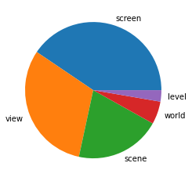

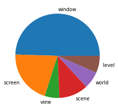

```python
closed_tot = (make_table_by_q(total, 'ClosedScreen').sort_values(by='All', axis=1, ascending=False))
display(closed_tot)
# Michael thinks two pie charts for results based on version
closed_tot = closed_tot.drop(labels="All", axis=1)
display(closed_tot)
labels = ['window', 'screen', 'view', 'scene', 'world', 'level']
labels_v1 = labels[1:]
v1_data = closed_tot.iloc[0]
v1_data = v1_data[1:6]
# print(labels_v1)
v2_data = closed_tot.iloc[1]
v2_data = v2_data[:6]
#ax1, ax2 = plt.subplot()
# nppg = state_total.iloc[1]
v1_pi = plt.pie(v1_data, labels = labels_v1)
plt.show()
v2_pi = plt.pie(v2_data, labels=labels)
plt.show()
```

Not including 'window' in V1 affected results. V2 suggests 'window' is popular option, 'screen' as second option.

## ClosedMovement

```
ClosedMovement contingency table
```

| ClosedMovement Version | Action | Animation | Glide | Movement |
| --- | --- | --- | --- | --- |
| 1 | 3 | 7 | 33 | 33 |
| 2 | 5 | 50 | 30 | 23 |
| All | 8 | 57 | 63 | 56 |

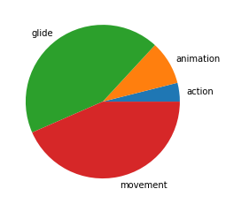

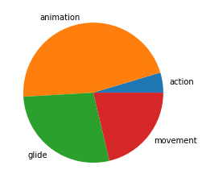

```python
movement_tot = make_table_by_q(total, 'ClosedMovement')
movement_tot = movement_tot.drop(labels="All", axis=1)
display(movement_tot)
labels = ['action', 'animation', 'glide', 'movement']
v1_data = movement_tot.iloc[0]
v2_data = movement_tot.iloc[1]
v1_pi = plt.pie(v1_data, labels = labels)
plt.show()
v2_pi = plt.pie(v2_data, labels=labels)
plt.show()
```

'animation' more popular. Difference from V1 and V2 was wording changed to manage bias. Obviously, significant difference, suggests wording affects participant perception and bias.

# Open-Ended Coding Question

Observe distributions and patterns in separate V1 and V2 data.

```
V1:
```

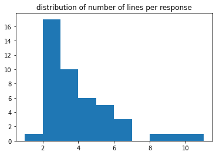

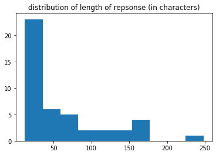

```
Num Lines Normality on an interval of .05:  0.8001936078071594 2.4016699171625078e-06 True
Num Characters Normality on an interval of .05:  0.7900149822235107 1.4448777392317425e-06 True

Broken: 6; Working: 70
{'methods': 18, 'functions': 15, 'both': 2, 'test cases': 0, 'graphics': 0, 'pens': 0, 'for': 3, 'while': 2, 'if': 2, 'func def': 7}
V2:
```

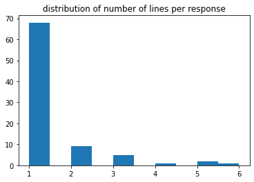

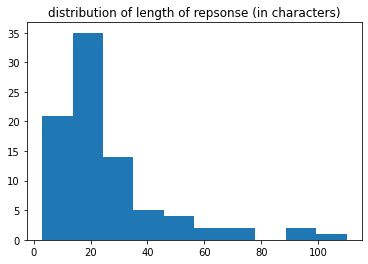

```
Num Lines Normality on an interval of .05:  0.4858640432357788 7.884292787326171e-16 True
Num Characters Normality on an interval of .05:  0.7452929019927979 6.568793425865138e-11 True

Broken: 34; Working: 84
{'methods': 31, 'functions': 11, 'both': 1, 'test cases': 0, 'graphics': 0, 'pens': 0, 'for': 0, 'while': 1, 'if': 2, 'func def': 5}
```

```python
print('V1: ')
print(analyze_open_end(v1, 'GameDevOpenCode'))
print('V2: ')
print(analyze_open_end(v2, 'GameDevOpenCode'))
```

All p-values are less than 0.05, meaning we reject the null hypothesis that line or character length of either survey version are normally distributed. Because these values are not normally distributed, we can perform Mann Whitney U tests to compare the version one and version two responses.

```python
v1_char_line = avg_lines_char(v1, 'GameDevOpenCode')
v2_char_line = avg_lines_char(v2, 'GameDevOpenCode')
line_mwu, line_mwu_p = st.mannwhitneyu(x=v1_char_line[0], y=v2_char_line[0])
char_mwu, char_mwu_p = st.mannwhitneyu(x=v1_char_line[1], y=v2_char_line[1])
print(line_mwu_p, char_mwu_p)
```

```
1.1529999803013193e-16 1.8128938277980706e-06
```

both p-values comparing line and character numbers are significantly small, less than 0.05, so we reject the null hypothesis that there are no statistically significant differences of response length and survey version. This suggests responses cannot be compared together and should instead be looked at separately.

```python
def attrib(code):
    clear_report()
    code = str(code)
    calls = find_asts("Call", code)
    num_for = len(find_asts("For", code))
    num_while = len(find_asts("While", code))
    num_assign = len(find_asts("Assign", code))
    num_def = len(find_asts("FunctionDef", code))
    called_functions = [get_called_function(c.func) for c in calls]
    call = False
    for c in calls:
        if (c.func.ast_name == "Name") or (c.func.ast_name == "Attribute"):
            call = True
        else:
            call = False
    try:
        code = str(code)
        ast.parse(code)
        working = True
    except SyntaxError:
        working = False
    if code == 'nan':
         return "empty"
    elif num_def:
        return "function definition"
    elif num_for or num_while:
        return "other construct"
    elif call:
        return "method/function call"
    elif num_assign:
        return "assignment"
    elif '#' in code or "'''" in code or '"""' in code:
        return "comment"
    elif not working:
         return "did not compile"

def open_by_version(df):
    return df.groupby(['Prior', 'PriorGameDev'])['GameDevOpenCode'].apply(attrib).count()
```

Classify responses based on conventions

```python
def open_by_version(df):
    classified = df.assign(classification=df.GameDevOpenCode.apply(attrib))
    grouped_classes = classified.groupby(['Prior', 'PriorGameDev']).classification
    classes_counts = grouped_classes.value_counts()
    return classes_counts.unstack().fillna(0).astype(int)
# display(open_by_version(pd.concat([v1, v2])).loc[(False,  'No.')])
v1_open = open_by_version(v1).loc[False,'No.']
v1_open = v1_open.div(v1_open.agg(sum)).multiply(100).round(1)
display(v1_open)
v2_open = open_by_version(v2).loc[False, 'No.']
v2_open = v2_open.div(v2_open.agg(sum)).multiply(100).round(1)
display(v2_open)
# ax = plt.subplot()
# pd.plotting.table(ax, data=v2_open)
open_total = pd.concat([v1_open, v2_open], axis = 1)
open_total.columns = ['V1', 'V2']
open_total = open_total.transpose()
# open_total.drop(['comment', 'function definition'], axis=1)
open_total = open_total.fillna(0)
open_total
```

```
classification
assignment               0.0
comment                  0.0
did not compile         16.7
empty                   38.9
function definition      5.6
method/function call    33.3
other construct          5.6
Name: (False, No.), dtype: float64
```

```
classification
assignment               2.1
did not compile         39.6
empty                   22.9
method/function call    35.4
other construct          0.0
Name: (False, No.), dtype: float64
```

| classification | assignment | comment | did not compile | empty | function definition | method/function call | other construct |
| --- | --- | --- | --- | --- | --- | --- | --- |
| V1 | 0.0 | 0.0 | 16.7 | 38.9 | 5.6 | 33.3 | 5.6 |
| V2 | 2.1 | 0.0 | 39.6 | 22.9 | 0.0 | 35.4 | 0.0 |

Get names of methods and functions called in responses

```python
def get_name(node):
    if isinstance(node.astNode, ast.Name):
        return node.id
    elif isinstance(node.astNode, ast.Attribute):
        return f"{get_name(node.value)}.{node.attr}"
def find_calls(code):
    clear_report()
    return [get_name(c.func) for c in find_asts("Call", code)]
calls = pd.concat([v2]).GameDevOpenCode.fillna("").apply(find_calls)
pd.Series(calls.sum()).value_counts()
```

```
frog.right           6
move_frog            4
glide                3
print                2
move_right           2
character            2
move                 2
right                1
frog_move_right      1
input                1
turtle.Turtle        1
move.frog            1
Run_frog             1
turtle.right         1
move_object_right    1
frog.left            1
forward              1
frog_slide           1
frog.forward         1
moveForward          1
frog.setx            1
glide_right          1
moveSprite           1
step_right           1
move_left            1
frog.slide           1
loop                 1
move_LR              1
moveLeft             1
movement             1
frog.glide           1
turtle.forward       1
move_sprite          1
dtype: int64
```